# Exploratory Analysis

## A Comprehensive Analysis of HIV/AIDS Epidemiological Trends in New York City

### Authors

- Akshata Aravind - aksh353@uw.edu
- Michelle Ndugulile - mndugu@uw.edu
- Saikrishna Pappuru - spappuru@uw.edu
- Thao-Nguyen Ho - uwthao07@uw.edu

### Date

Summer 2023

### Abstract

Our main question is how has HIV prevalence changed overtime in various sub-populations of New York City throughout 2011-2015? This question is important because analyzing population data is significant to understanding the nature of the spread of immunodeficiency diseases in our populations. Using this dataset, our project aims to showcase which demographics are most affected by the HIV epidemic in New York City and how this analysis can possibly contribute to creating targeted public health interventions and solutions.

### Keywords

1. Epidemiology
2. Public Health
3. Immunodeficiency Disease
4. Global Epidemic

### Introduction

While our main research question encompasses analyzing the prevalence of HIV overtime in various sub-populations of New York City, there are numerous other questions that can be posed about this extensive dataset. For instance, investigating a plausible correlation between gender and the risk of contracting HIV. Additionally, this dataset can lead to investigating disparities in HIV prevalence among different racial and ethnic groups in New York City, highlighting the impact of racial background when it comes to healthcare. Bouncing off our main research question, another topic that emerges is if geographical clusters or hotspots of HIV transmission are present.

Overall, these are a combination of research questions that will be analyzed under this dataset. Understanding the primary target population and how the HIV disease may affect people differently based on gender, race, and location can significantly impact prevalence and subsequent treatment for patients. It is important to analyze and research these questions since there are many social determinants of health that shape the healthcare experience and treatments for individuals. These unique data analyses and paths of inquiry can contribute to creating more personalized healthcare that addresses key issues and causes of diseases amongst populations, such as HIV transmission throughout New York City.

Research Questions:

- How has HIV prevalence changed overtime in various regions and sub-populations of New York City throughout 2011-2015?
- Which groups of people/populations are most likely to contract HIV?
- Is there a correlation between gender and the risk of contracting HIV/AIDS? Do gender attitudes and behaviors contribute to that risk?
- How has the death rate changed over time? What factors might cause this trend?
- Are there any geographical clusters or hotspots of HIV transmission?

### Related Work

HIV is a retrovirus that attacks the immune system of the body, primarily CD4+ T cells, which are essential for fighting off infections. The immune system gradually deteriorates as the virus replicates and kills these cells, making an individual more susceptible to a variety of opportunistic infections. AIDS develops when the immune system is significantly damaged and the CD4+ T cell count falls below a critical level.

HIV/AIDS prevalence refers to the percentage of people living with the virus at a given point in time. Looking specifically at the state of New York’s prevalence, these sources emphasize the fluctuation in HIV diagnoses over the past 35 years. The two NY State Surveillance Annual Reports specifically pull data for each NY borough up until the year 2015 - data that can correspond to our chosen project dataset. The remaining articles assess the decline and rise of diagnoses from 2019 - 2021 to further assess the impact the virus has had on various communities in New York.

This data serves as an essential epidemiological indicator that aids in understanding the impact of HIV/AIDS in a given community. Understanding its prevalence is crucial in helping to facilitate a design of focused interventions to prevent transmission and to enhance health outcomes for people living with HIV/AIDS. Monitoring changes in prevalence over time can help public health professionals evaluate the impact and effectiveness of preventive measures, and to therefore assess new strategies to encourage the success of curbing the spread of the virus.

Citations:

- HIV Epidemiology Program. *HIV Surveillance Annual Report, 2020*. New York City Department of Health and Mental Hygiene: New York, NY. December 2021. https://www.nyc.gov/site/doh/about/press/pr2021/new-hiv-diagnoses-declined.page
- *New York State HIV/AIDS County Surveillance Report*, https://www.health.ny.gov/diseases/aids/general/statistics/annual/counties/annual_rpt_including2014.pdf. Accessed 27 July 2023.
- “Local Data: New York State.” *AIDSVu*, 2 Dec. 2020, https://aidsvu.org/local-data/united-states/northeast/new-york/
- Mandavilli, Apoorva. “H.I.V. Infections Remain Persistently High, U.N. Reports.” *The New York Times*, 27 July 2022, https://www.nytimes.com/2022/07/27/health/hiv-infections-unaids.html

### The Dataset

Where did you find the data? Please include a link to the data source

- We found the data through this [data.world](https://data.world/city-of-ny/fju2-rdad) page.

Who collected the data?

- New York City collected the data to submit to the Department of Health and Mental Hygiene (DOHMH) for the HIV Surveillance Annual Report.

How was the data collected or generated?

- Based on the CDC (Centers for Disease Control and Prevention) website, the HIV Surveillance data is collected from persons with diagnosed HIV infection.

Why was the data collected?

- The data was collected to provide an overview on the current epidemiology (distribution and determinants of health) of HIV disease in the U.S. and dependent areas. This specific dataset was collected for New York City’s surveillance of HIV through the years of 2011-2015.

How many observations (rows) are in your data?

- There are 6,005 observations (rows) in the dataset.

How many features (columns) are in the data?

- There are 18 features (columns) in the dataset.

What, if any, ethical questions or questions of power do you need to consider when working with this data?

- There are many ethical questions and questions of power that need to be considered when working with data. Firstly, this dataset deals with personal healthcare information, which can fringe on patient privacy if not collected or analyzed carefully. Since HIV is a sensitive topic in society as a result of taboo and stigma over the years, one key question of power that comes to mind is how transparent is the data collecting process to the participants? Did they get informed of how their data will be stored and used? Furthermore, healthcare access and resources in the U.S. vary based on demographics and social determinants of health, which leads to the ethical question of who has access to the healthcare resources to be able to get tested for HIV? These are a few of the most significant ethical questions and questions of power that revolve around this HIV Surveillance dataset.

What are possible limitations or problems with this data? (at least 200 words)

- There are a few possible limitations with this HIV Surveillance data. For instance, not all HIV cases may be reported through the surveillance system as some individuals may be unaware of their HIV status. Many people may not even test for HIV as healthcare education in various locations vary (lack of healthcare education results in lower test rates), while others may not wish to test as a result of social pressures and stigma. This could ultimately lead to underestimations in HIV prevalence in the data. Additionally, another limitation is that certain key populations may be underrepresented in the data due to reluctance to engage with healthcare workers or lack of access to healthcare services. Certain populations and marginalized populations, such as unhoused populations, may face this reluctance to engage with healthcare and legal systems, resulting in an overrepresentation of populations that may not be highly affected by HIV prevalence and transmission. Furthermore, although this dataset extensively covers demographic and clinical information - such as, age, gender, race, location, concurrent diagnoses, viral suppressions, etc.- this dataset does not cover behavioral backgrounds on the demographics. Behavioral backgrounds would include sexual behaviors, substance behaviors, and genetic patterns that could shape the context of individuals within the dataset. This is a limitation that results in the lack of understanding of personal stories and experiences of HIV prevalence, which is key in understanding the spread of the disease in addition to the demographic/clinical factors to illustrate a whole story with perspective and depth.

### Implications

Our research project’s examination of HIV’s epidemiological trends in NYC carries significant implications. These can range from influencing the development of technological solutions, guiding the design of effective public health interventions, and informing policy-making to unearth deeper health disparities.

For technologists, the insights derived from this comprehensive dataset could lead to transformative developments in the healthcare domain. By uncovering trends in HIV prevalence, technologists can develop predictive models and informatics solutions that improve detecting and monitoring the outbreaks. However, a potential negative implication might be misinterpreting the data, which may lead to inaccurate predictions.

Designers can benefit by gaining a better understanding of the demographics that are most affected by the HIV epidemic. This knowledge can guide the creation of culturally sensitive and targeted health campaigns, informational materials, and digital interfaces that resonate with and effectively educate these populations. However, the potential negative implication is that if the data is not interpreted with care, designers could unintentionally stigmatize or stereotype certain populations, causing further harm.

For policymakers, the research findings could provide valuable evidence to inform and influence health policies. The trends and patterns identified could guide decisions on resource allocation, implementation of preventive measures, and crafting of interventions to address the HIV/AIDS issue more effectively. A potential negative implication here is that the data might reveal gaps or shortcomings in existing policies, necessitating difficult changes or acknowledging failures in previous approaches. However, these revelations, while challenging, are crucial for driving improvement in public health policy and outcomes.

### Limitations & Challenges

- **Data Availability and Quality**: The reliability of the data may be compromised depending on the different sub-populations and geographies in New York City from 2011 to 2015. Some demographic groups may have been underrepresented in the data collecting and reporting systems, which might have influenced the study.
- **Ethics and Confidentiality**: Since HIV/AIDS data comprises private and sensitive information, ethical questions about permission and privacy are raised. In order to safeguard the privacy of the subjects, it is important to consider that the data may not reflect all individuals with HIV/AIDS in each borough, based on an individual not wanting to share status.
- **Causality vs. Correlation**: The project aims to identify correlations between certain variables and HIV/AIDS prevalence, but establishing causality can be complex. Determining clear cause-and-effect linkages is difficult since many other factors, including gender attitudes and behaviors, may have had an impact on risk factors for HIV/AIDS.
- **Sample Representation**: It might be challenging to guarantee the representation of the sample while studying several sub-populations. Some populations may have had low numbers, or might have been difficult to contact, leading to possible bias and restrictions on generalizing the data.

### Summary Information

Write a summary paragraph of findings that includes the 5 values calculated from your summary information R script

- Based on the analysis of the provided data, we found that there was an average of 26.4945878 HIV diagnoses annually. The mean HIV diagnosis rate was 119.5014988 per 100,000 population, indicating a significant prevalence of the disease. Over the course of the data collection period, there were a total of 296932 deaths reported. The impact of the disease seems to be more severe among males, with 93251 males affected by HIV, compared to 25844 females. This data underscores the importance of gender-sensitive approaches to HIV prevention and treatment strategies. The information provided by this data provides valuable insights into the HIV/AIDS situation in the area and can guide future research and public health initiatives.

### Table

Include a table of aggregate information

Describe why you included the table and what information it reveals

- We include the table below to provide a summarized view of the HIV situation across different boroughs in the dataset. This aggregate view allows us to quickly compare and contrast the impact of HIV among different boroughs, as well as between different genders within those boroughs.

Aggregate HIV data by Borough.

| Borough | Total_HIV_Diagnoses | Total_Deaths | Females_Affected_HIV | Males_Affected_HIV |
| --- | --- | --- | --- | --- |
| All | 58320 | 36764 | 9062 | 34448 |
| Bronx | 21868 | 219436 | 5103 | 11298 |
| Brooklyn | 30472 | 18248 | 5925 | 16929 |
| Manhattan | 28124 | 13792 | 2856 | 18237 |
| Queens | 18584 | 6588 | 2502 | 11436 |
| Staten Island | 1732 | 2104 | 396 | 903 |

### Chart 1: HIV Diagnosis by Gender from 2011 to 2015

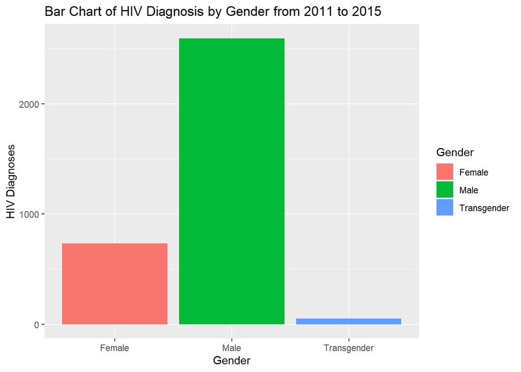

This chart is a visual representation depicting the number of HIV diagnoses by gender from 2011 to 2015 in the state of New York.

### Purpose

The bar chart illustrates the distribution of HIV diagnoses among different genders. Each gender is represented by a bar, and its height reflects the respective number of HIV diagnoses. This visual aid allows us to easily compare HIV diagnosis patterns across genders from 2011 to 2015. Examining these patterns allow for analysis of gender-specific disparities in HIV transmission, providing valuable and more targeted insights into public health protocols.

### Insights

-The “ALL” category from the gender variable was excluded when plotting the bar chart. By omitting this category, which aggregates diagnoses across all boroughs in the state of New York, the focus remains on the distinct gender-specific trends totaled from boroughs.

### Chart 2: HIV Diagnoses Across Different Race between 2011 and 2015 in NYC

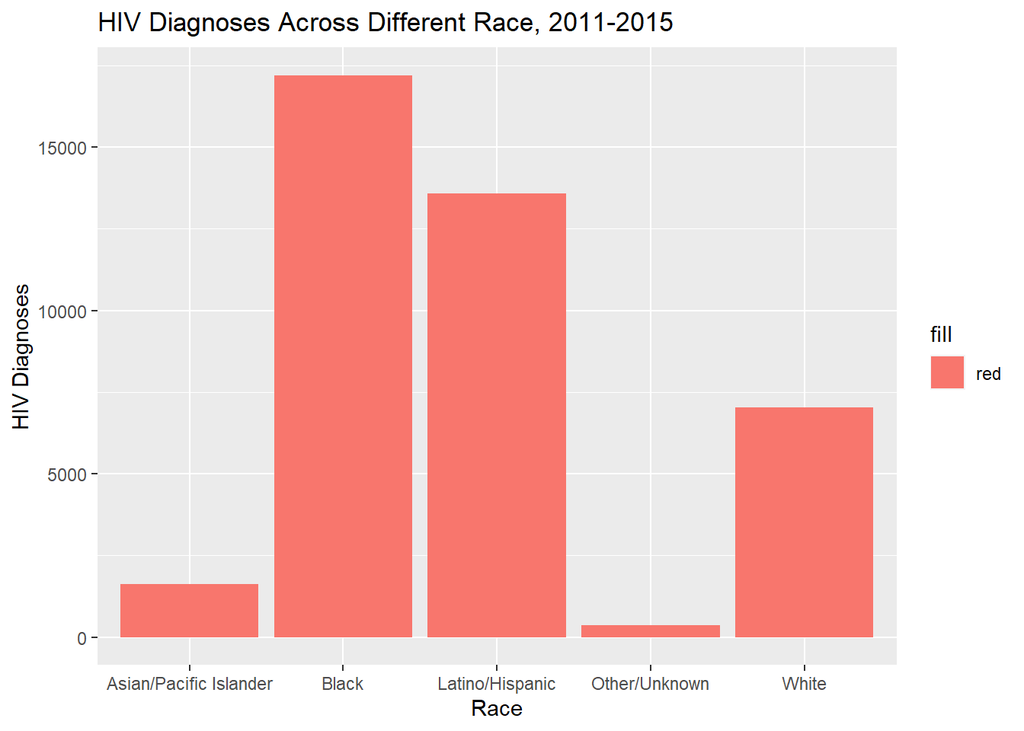

This chart visualizes the HIV diagnoses across different racial groups from 2011 to 2015 in NYC.

#### Purpose

By comparing the HIV diagnoses across different racial groups, this chart seeks to express which group is the most likely to contract HIV. The chart allows us to understand which group needs more attention and resources in reducing the risk of contracting HIV and allows us to explore the underlying systems/factors that cause the group to have the highest HIV rate.

### Chart 3: HIV and AIDS Related Death Rate Overtime (2011-2015) in New York

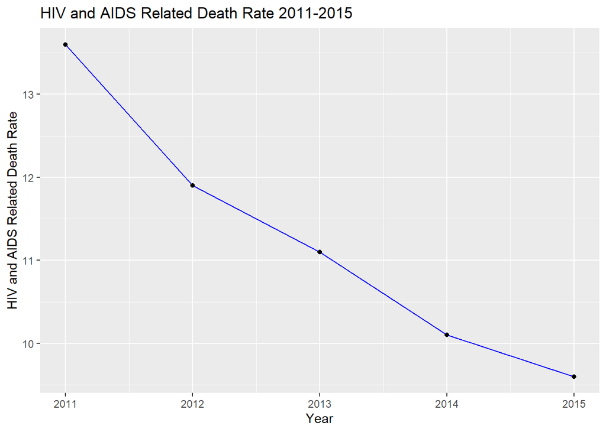

This chart illustrates the trend of HIV and AIDS related death rate over time from the years of 2011-2015 in New York. Each point represents the HIV and AIDS related death rate for the designated year and showcases the correlation between these two variables.

#### Purpose

By graphing the correlation between HIV and AIDS related death rate and year, this chart allows us to observe the trend of how HIV and AIDS has affected mortality of those who have the disease over the years of 2011-2015. This chart allows us to analyze whether the HIV/AIDS epidemic has been increasing, decreasing, or stabilizing overtime in New York. Furthermore, the illustrated trend in the chart can be used to provide insight into public health interventions, campaigns, and overall HIV/AIDS treatment effectiveness in New York from 2011-2015.

#### Insights

- There is a significant **downward trend** in the HIV and AIDS related death rate from 2011-2015
  - Overall, the death rate decreases from **13.6 in 2011** to **9.6 in 2015**
  - The magnitude of change in the death rate is notable at 4.0 points
- The downward trend suggests **improvement in sexual & health education and treatment efficiency** targeting HIV and AIDS mortality
  - This trend may be influenced by the increase of awareness campaigns, testing access, and treatment support from NYC health in New York throughout 2011-2015.